# Grassland Obligates and Declining Birds Operate Near Edges of Body Mass Distributions

##### Taxonomic munging of the census data

Although the NABBS survey reports species-specific abundances, some birds are only classified to genera or order. Common examples of these species are those which are nearly indistinguishable from each other (e.g., Glossy Ibis and White-faced Ibis), birds which are difficult to see under certain conditions (e.g., hummingbirds, fast-moving hawks or accipiters), or speices whose songs are similar. Numerous species were presented as identified to family or genus (e.g., Accipiter sp., Buteo sp., and Trochilids sp.) and others are categorized as hybrid.

I made decisions regarding species-specific classification based on the North American breeding range maps provided by the Cornell Lab of Ornithology. Many unidentified species were easily categorized given the lack of overlap in species’ ranges in our study area. For example, *Baeolophus bicolor* is nearly indistinguishable from *Baeolophus atricristatus*, however *B. atricristatus* is not known to occur in our study area (Figure @ref(fig:studyarea))–therefore all accounts classified as either *B. bicolor* or *B. atricristatus* were classified as the former. This example occurred for. Informed decisions like of this nature were made regarding the following unidentified species, where the second name in the binomial was assigned as the species preceding the “/”: *Passerina cyanea / amoena*, *Corvus brachyrhynchos / ossifragus*, *Petrochelidon pyrrhonota / fulva*, *Corvus brachyrhynchos*, *Quiscalus major / mexicanus*, *Pipilo maculatus / erythrophthalmus*, *Sturnella magna / neglect*, *Plegadis chihi / falcinellus*, *Coccyzus erythropthalmus / americanus*, *Empidonax traillii / alnorum*, *Icterus galbula / bullockii*, *Nyctanassa nycticorax / violacea*, and *Poecile atricapillus / carolinensis* were all classified according to their known distributions. I classified unidentified hummingbirds (*Trochilid* sp.) as *Selasphorus rufus*,and unidentified Terns (Tern sp.) as *Childonias niger*. All unidentified Accipiters (Accipiter sp.), Buteos (Buteo sp.), and Gulls (Gull sp.) were removed from analysis etirely as there are no clear differences in the probability of occurrence in our study area.

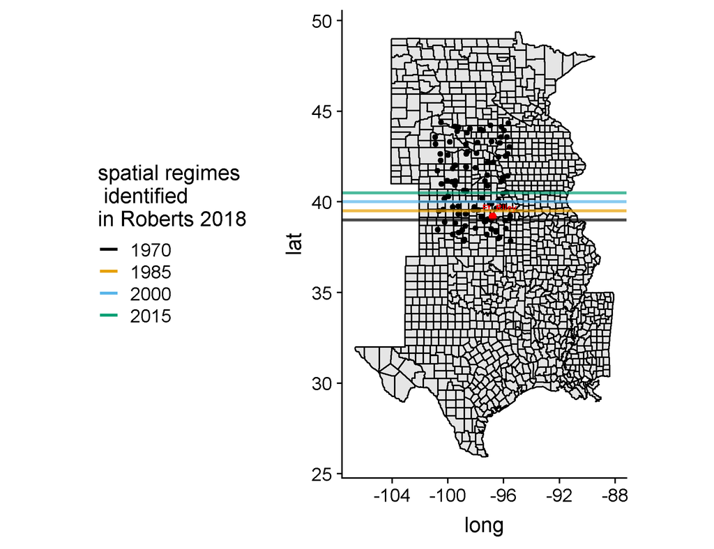

North American Breeding Bird Survey routes (points), latitudinal locations (horizontal bars) of the spatial regimes identified by @roberts2019shifting.

#### Identifying species of interest

@allen2006patterns propose alternative hypotheses for the relative locations of species within the body mass aggregation distributions as a function of ‘distance-to-edge’, a measure indicating the distance (in log-mass units) of each species to the edge of a body mass aggreagtion (methods described in Section @ref(discontAnaly)). This distance-to-edge measure is zero when the species falls at the edge of a statistically identifed body mass aggregation. This species is often referred to as an ‘edge species’. To determine the effect of spatial regime shifts on edge species, I identified three types of species of interest: (1) grassland obligates species, (2) species with widespread population declines in the study area, and (3) a combination of these groups. All remaining species were classified as ‘other’.

##### Grassland obligate species

The spatial regimes identified in @roberts2019shifting are attributed to large-scale changes in the landscape, including woody plant invasion. The loss of native grassland in our study area due to land conversion is largely attributed to anthropogenic land use change (e.g., development) and fire suppression. Numerous species have been negatively impacted by this widespread habitat loss, but grassland obligates are particularly at risk. Grassland obligates should be strong indicators of the large-scale spatil regime shifts identified in @roberts2019shifting, given their high sensitivity to grassland habitat loss [@herkert1994effects]. I identified North American grassland obligate species from the grey literature [@shriver2005distribution; @north2009state] and white literatures [@peterjohn1999population]. Although some grassland obligates were positively impacted by the Conservation Reserve Program [CRP; @peterjohn1999population], this group of birds exhibited strong declines in North America until approximately 2003, the year the Farm Bill was adopted [@north2009state].

##### Declinling species

I classified a species as ‘declining’ based on the results of the North American Breeding Bird Survey [@sauer2017results]. The Patuxent Wildlife Research Center uses hierarchical modelling techniques to estimate the trends of species using the NABBS data at various spatial scales. @sauer2017results also provides estimates of data credibility according to data availability, number of routes used to build the population trend estimate, abundance, and probability of detecting a small change in population trend. These credibility scores are generated for multiple spatial extents: state-level, BCR-level, and across the three regions of the United States (Western, Central, and Eastern). Given the extent of this study, I considered the data credibility estimates using the Central Breeding Bird Survey Region, the Prairie Pothole BCR (BCR 11) and Eastern Tallgrass Prairie (BCR 22). A species was considered as declining only if the trend estimate was categorized as having moderate precision and abundance (blue) or having a deficiency (yellow). I considered the population trend estimates provided for the period of 1966 - 2015.

### Statistical analysis

#### Identifying scaling structure of avian communities using body mass distributions

Discontinuities in body mass distributions been quantified using various methods (e.g., multivariate time series models, regression trees, and gap rarity index) which are collectively referred to as ‘discontinuity analyses’ [@nash2014discontinuities; @barichievy2018method; @stow2007evaluating; @allen2006discontinuities]. Using various methods, the discontinuous nature of body masses of ecological communities is well-documented, having been observed in various taxa of both terrestrial [@allen2006patterns] and aquatic [@spanbauer2016body] communities. Multiple methods are proposed for identifying discontinuities in body mass aggregations [@allen2001cross], including clustering algorithms [@stow2007evaluating], body mass difference indices [@holling1992cross], gap rarity index [@restrepo2008discontinuities], and more recently the discontinuity detector [@barichievy2018method], an extension of the gap rarity index [@restrepo2008discontinuities].

I used the discontinuity detector described in @barichievy2018method, which uses likelihood to determine whether the observed data contains multiple modes as compared to that of a Gaussian (unimodal) distribution. This method requires multiple user-defined parameters, including an imputation resolution (1000) and a bootstrap sample size (1000) over which the null distribution is randomly sampled. I provided a slightly altered and annotated version of the functions `Neutral.Null` and `Bootstrap.Gaps` (first printed in @barichievy2018method) used to identify discontinuities in a continuous variable in Appendix @ref(appDiscont). Two criterion have been used to determining the exact location of discontinuities within a rank-ordered continuous variable: using a constant significance/threshold level [@barichievy2018method] and a power constant table for varying sample sizes [@roberts2019shifting]. It should be noted because the power-constant method identifies a larger proportion of “significant” discontinuities, or edges, identifying aggregations requires subjective measures regarding actual aggregation locations. Using the percentile method avoids this subjectivity, however, the aggregation number and locations are sensitive to choice of percentile or threshold value. Following the methods of @barichievy2018method I considered a value to be a discontinuity if the gap percentile (see Appendix @ref(appDiscont) was $\geq 90%$. I built route-level body mass distributions for each route-year combination by using presence absence data from the current, previous, and following year to account for observational and process errors impacting the detectability of a species within a single route. Using this method reduces the amount of species-specific, and consequently specific-body mas turnover within a route over time. This also assumes that an unobserved species is truly absent, an assumption which is difficult to avoid without a sophisticated occupancy modelling approach for each species in the community.

#### Determining Effects of a Spatial Regime Boundary on Grassland Birds

If the spatial regime shift occurred in the bird community, it should manifest in the local community scaling structure through one or both of species turnover and a shift in the number of body mass aggreagsations. I used linear mixed modelling to determine whether the local scaling structure and the location of grassland obligates and declining species within these scaling structures are impacted by the spatial regime boundaries proposed by @roberts2019shifting.

I used a linear mixed model to determine whether the proposed moving spatial regime boundaries influenced the location of species of interest (grassland obligates, declining species) within their respective body mass aggregation. Each species was assigned a ‘distance to edge’, which served as a proxy of the proximity of a species to the nearest edge of its respective body mass aggreagtion. Previous studies suggest that this distance to edge measure can be used to identify zones of transitions, as invasive and threatened species tend to be located at the edges of aggregations [@allen1999body]. Following this hypothesis, one should expect to see changes in the locations of sensitive and declining species change in the areas undergoing so called spatial-regime shift zones [@roberts2019shifting].

## Results

### Summary statsitics of censuses (NABBS data)

#### Species of interest

The total (Figure @ref(fig:stopTotalSum)) and mean (Figure @ref(fig:stopTotalMean)) number of birds counted within each species group was relatively constant across time in the Praire Potholes and Eastern Tallgrass Prairie bird conservation regions, but fluctuation in stop totals appeared greater in the Badlands and Prairies BCR (Figures @ref(fig:stopTotalMean), @ref(fig:stopTotalSum))). The latter BCR comrprises a much smaller portion of the study area (Figure @ref(fig:studyarea)) and accordingly the coefficient of variation (CV; ratio of deviation to the mean) around the stop totals (Figure @ref(fig:stopTotalCV)) was highest in this region. It is worth noting the high CV (CV is considered low when $<\ \sim40%$) in all regions.

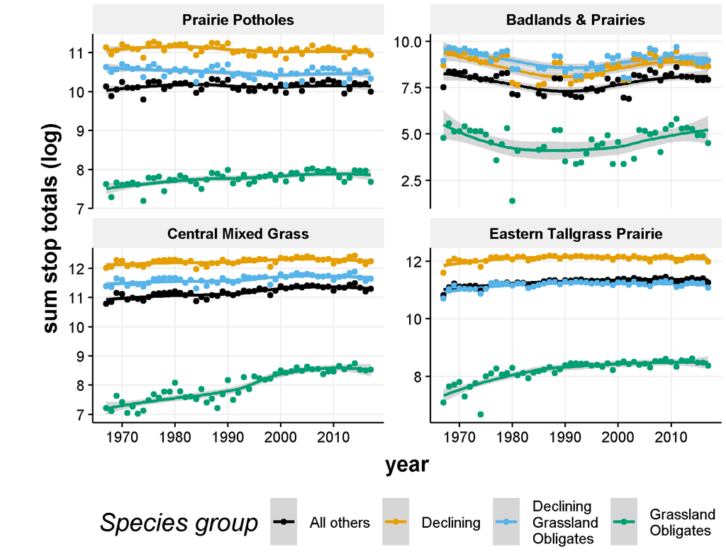

Total number of birds across the entire study area per species group per year.

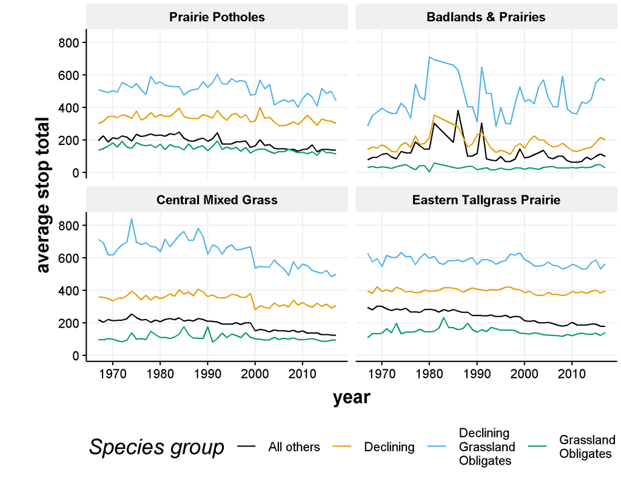

Average number of birds across the entire study area per species group per year.

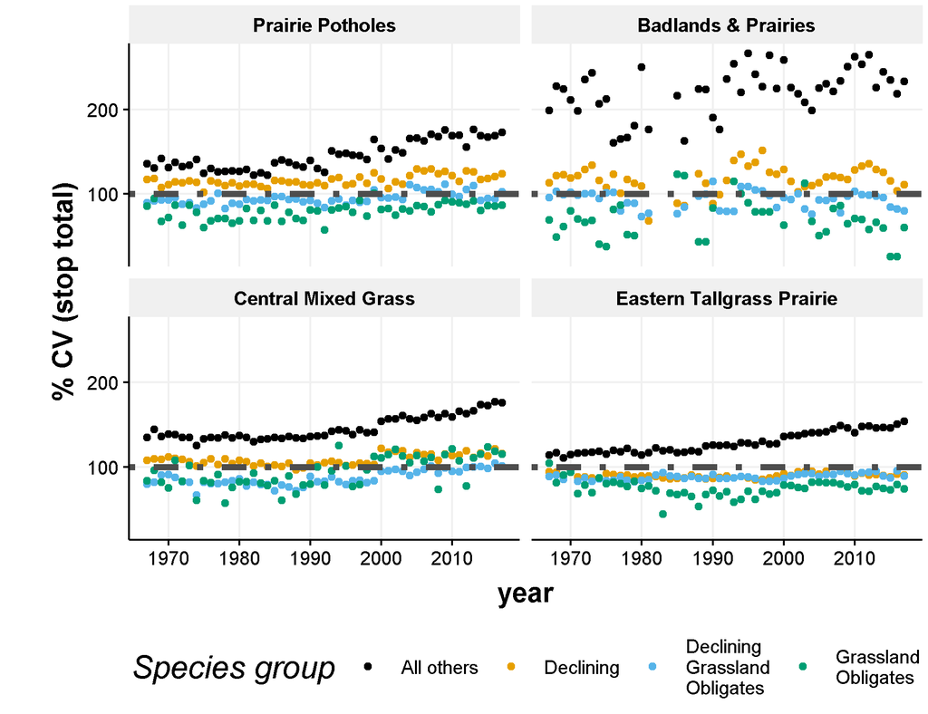

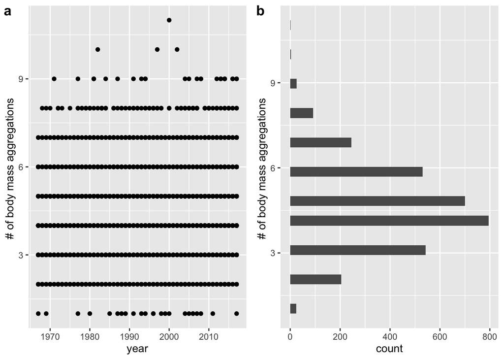

Number of body mass aggregations identified in each route unchanged across the time period (**a**) and is approximately normally distributed ($\bar{x} = 4.7, \sigma = 1.6$)

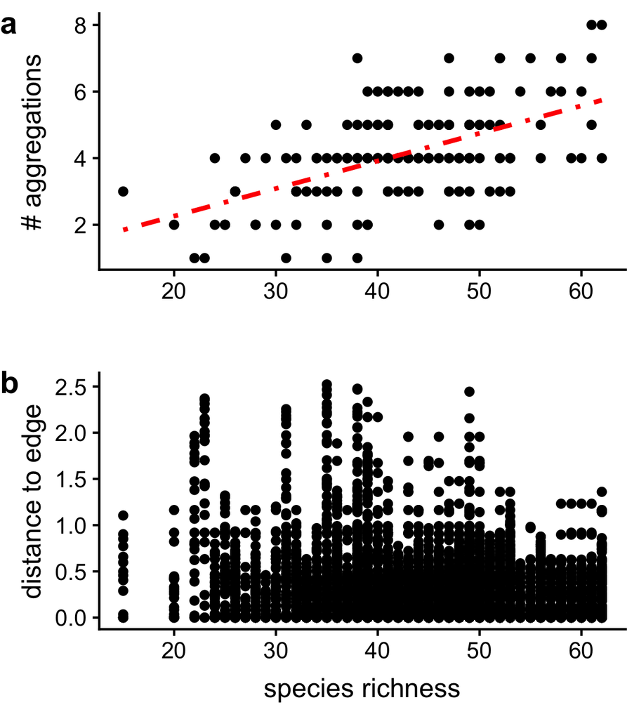

Relationship between species richness per route and (a) the number of aggregations identified in body mass distributions and (b) distance to the edge (units log body mass) of aggregations.

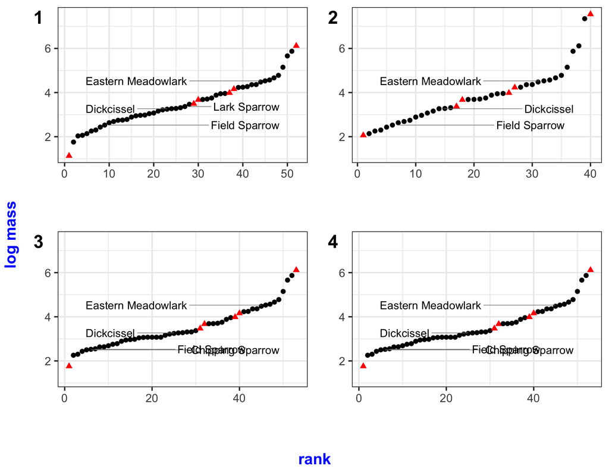

Aggregation locations of body mass distributions of the avian community at a single NABBS route (state 7 route 24) appear relatively similar across time.

### Statistical Analysis

#### Identifying scaling structure in body mass distributions

The discontinuities in the body mass distribution identified appeared relatively similar over time at most NABBS routes (Figure @ref(fig:routeGapEx)). If the shifting spatial regimes proposed in an earlier study [@roberts2019shifting; Figure @ref(fig:routesWithSpatRegimes)], then we should expect changes in the body mass distribution of NABBS falling within or near the regime boundary. This was not observed on the routes falling within this zone (Figure @ref(fig:routeGapEx) is representative of the ~5 NABBS locations falling in this area of expected changes shifting).

#### Linear Mixed Effects Analysis of Distance to Edge

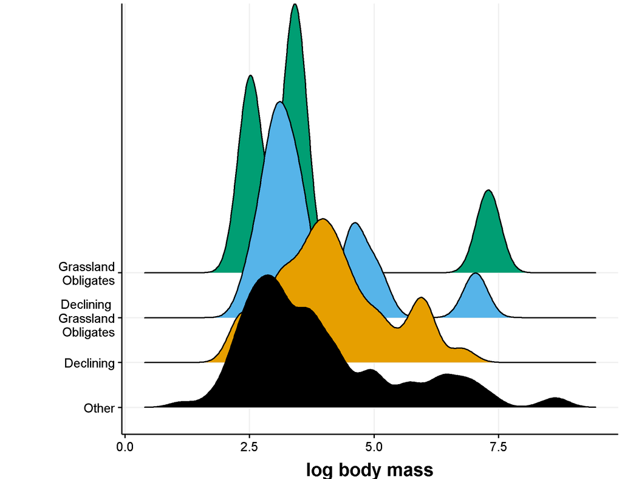

Body mass distribution for species in the study area over the entire time period varies by species group. Distributions represent the species pool for each group over the entire study area and all years.

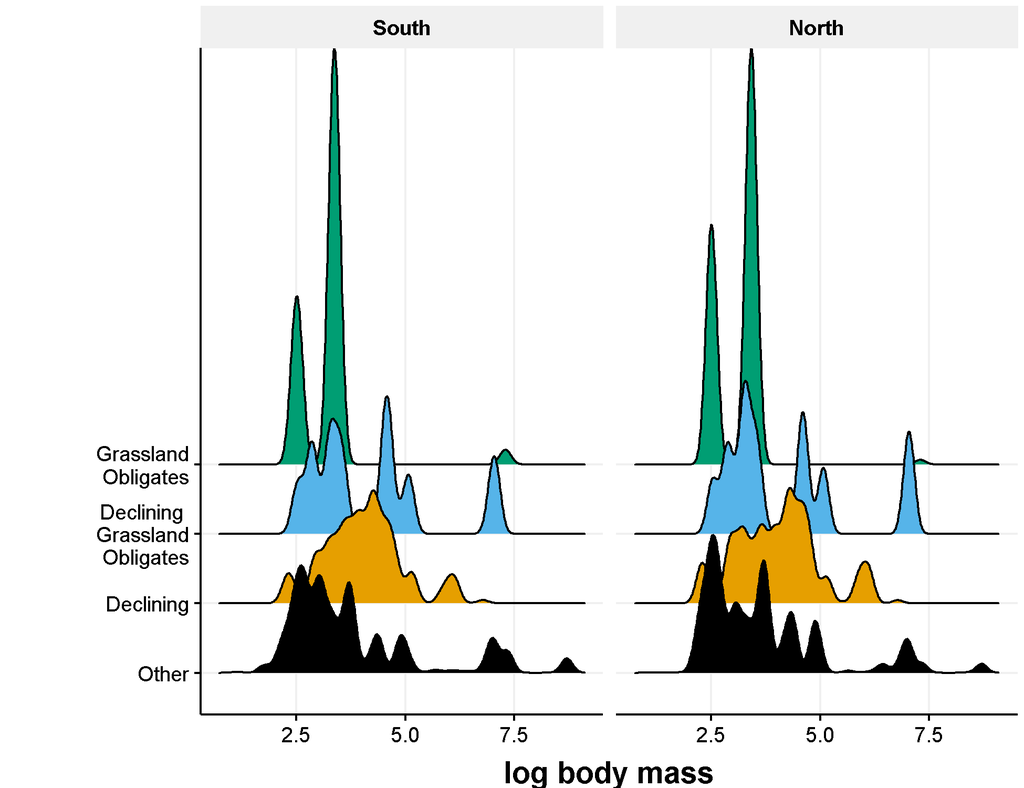

The body mass distribution of declining species appears to differ slightly between the Southern and Northern regimes.

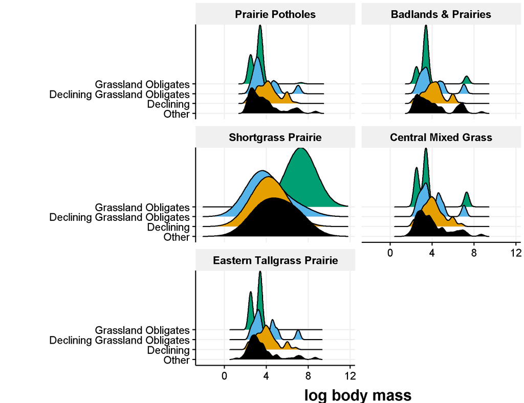

Body mass distribution for species in the study area over the entire time period varies by species group. Distributions represent the species pool for each group and Bird Conservation Region over all years.

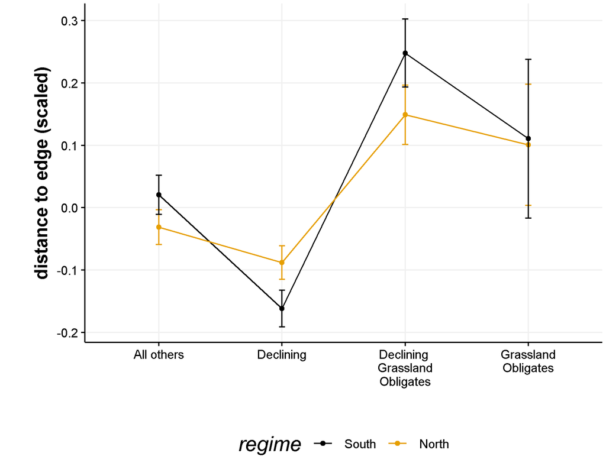

## Discussion

South-North shifts in the past 50+ years have been demonstrated in large scale processes, including bird populations and ranges [@sorte2007poleward] and plant hardening zones [@mckenney2014change]. The concept of spatial regimes was recently introduced as a way of describing or identifying large-scale shifts of this nature [@roberts2019shifting; @sundstrom2017detecting], despite the lack of rigorous testing on the methods used to identify these shifts. In this Chapter, I used discontinuity analysis of bird communities, under the assumption of a zone of shifting ‘spatial regimes’ [@roberts2019shifting] to determine whether local-scale changes in the scaling structure were impacted by these shifts. Although I found moderate support for the hypothesis that declining species operate at the edges of body mass aggregations, I did not find sufficient support for the impact of these proposed spatial regime shifts.

Although the body mass distiributions of terrestrial communities at small scales tends to differ from the distribution at larger spatial scales [@blackburn1994animal], numerous studies confirm the evidence for ‘discontinuities’ in these distributions at across scales for a variety of phenomenon [@wardwell2009variability; @allen1999body; @spanbauer2016body;@nash2014discontinuities]. The jury is still out, however, as numerous studies are finding a lack of evidence for discontinuities in their study sysytems [@siemann1999gaps;@bibi2019body; @manly1996there].

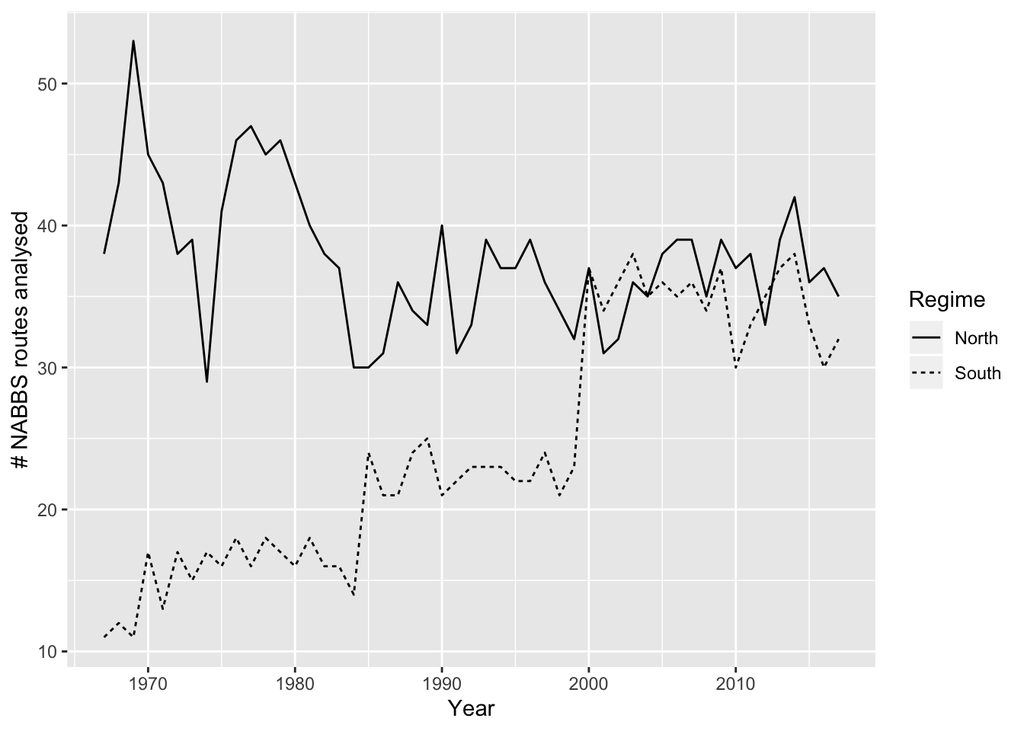

Number of NABBS routes analysed per year. Some routes are not sampled annually due to volunteer availability, environmental conditions, or route discontinuation.

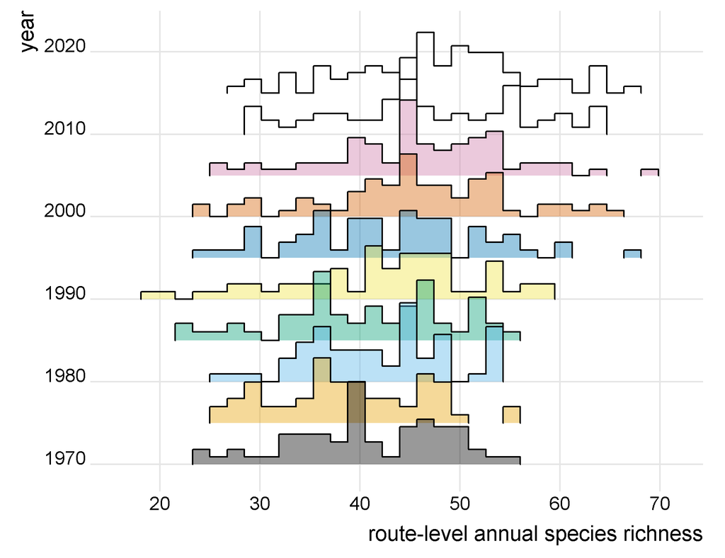

Species richness increases over time across the entire study area.

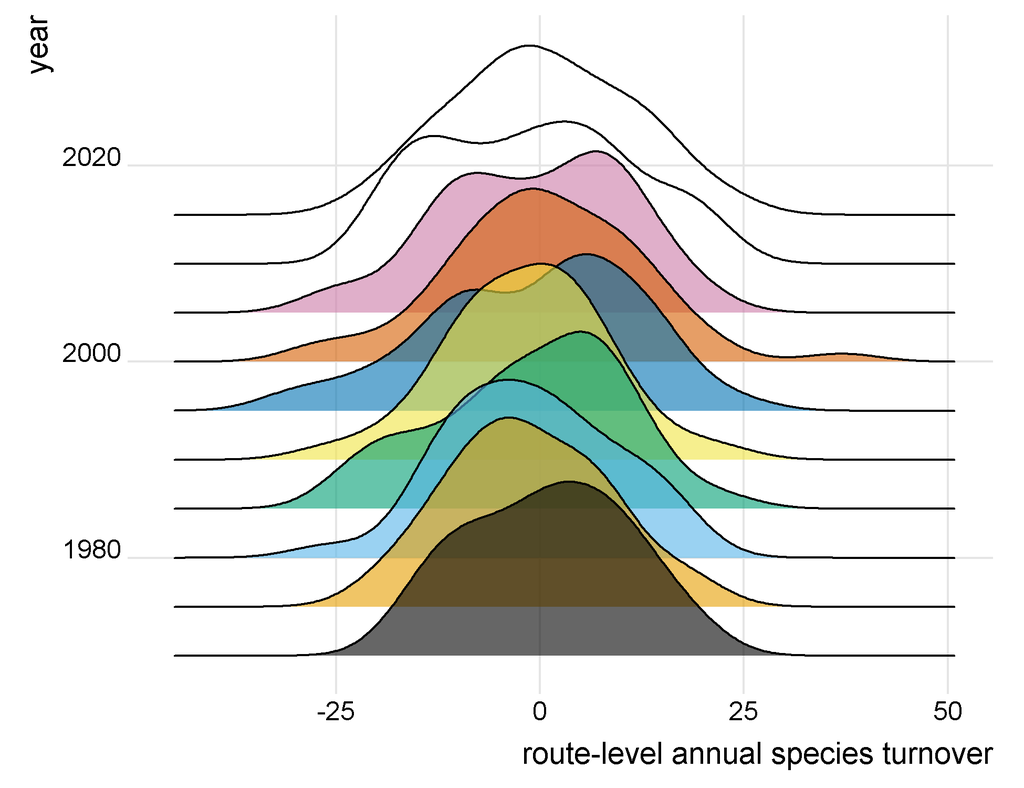

Variance in species turnover increases over time across the entire study area.

Summary statistics for annual species richness and annual turnover in all NABBS routes in study area.

| Year | Annual Richness $\bar{x}$ | Annual Richness $\sigma$ | Annual Richness N | Annual Turnover $\bar{x}$ | Annual Turnover $\sigma$ | Annual Turnover N |
| --- | --- | --- | --- | --- | --- | --- |
| 1967 | 39.4 | 8.14 | 27 | -0.1 | 8.13 | 27 |
| 1968 | 41.4 | 8.11 | 37 | 1.6 | 10.25 | 37 |
| 1969 | 39.9 | 7.44 | 47 | 0.6 | 10.12 | 47 |
| 1970 | 41.3 | 7.73 | 43 | 0.9 | 9.74 | 43 |
| 1971 | 39.4 | 7.50 | 36 | 0.7 | 10.62 | 36 |
| 1972 | 41.0 | 9.80 | 32 | -1.2 | 12.94 | 32 |
| 1973 | 40.1 | 8.33 | 33 | -2.1 | 10.42 | 33 |
| 1974 | 38.8 | 7.67 | 27 | -2.2 | 10.53 | 27 |
| 1975 | 38.3 | 7.37 | 32 | -1.4 | 9.57 | 32 |
| 1976 | 41.2 | 7.53 | 45 | 0.6 | 10.31 | 45 |
| 1977 | 39.5 | 8.48 | 43 | -1.7 | 9.69 | 43 |
| 1978 | 39.5 | 8.88 | 42 | -1.9 | 10.09 | 42 |
| 1979 | 39.7 | 8.06 | 43 | -1.7 | 10.03 | 43 |
| 1980 | 40.4 | 7.18 | 37 | -1.1 | 10.16 | 37 |
| 1981 | 41.2 | 8.76 | 39 | -1.2 | 9.26 | 39 |
| 1982 | 42.3 | 6.65 | 32 | -1.6 | 8.28 | 32 |
| 1983 | 41.3 | 8.47 | 33 | -1.9 | 8.91 | 33 |
| 1984 | 41.7 | 7.85 | 22 | -4.1 | 6.12 | 22 |
| 1985 | 40.8 | 8.54 | 34 | -1.1 | 11.30 | 34 |
| 1986 | 42.2 | 9.17 | 32 | -2.7 | 10.42 | 32 |
| 1987 | 43.4 | 8.94 | 38 | -1.3 | 9.82 | 38 |
| 1988 | 41.7 | 9.35 | 37 | -1.4 | 12.19 | 37 |
| 1989 | 42.3 | 8.67 | 40 | -1.8 | 9.98 | 40 |
| 1990 | 42.3 | 9.47 | 38 | -1.6 | 9.69 | 38 |
| 1991 | 43.3 | 9.69 | 30 | -2.1 | 10.14 | 30 |
| 1992 | 44.6 | 7.52 | 31 | -0.8 | 9.61 | 31 |
| 1993 | 42.7 | 9.35 | 41 | -1.0 | 12.87 | 41 |
| 1994 | 43.4 | 9.76 | 38 | 0.4 | 12.50 | 38 |
| 1995 | 42.2 | 9.98 | 39 | -0.8 | 12.75 | 39 |
| 1996 | 44.1 | 7.44 | 36 | 1.0 | 10.68 | 36 |
| 1997 | 44.6 | 9.45 | 39 | 1.0 | 12.65 | 39 |
| 1998 | 43.8 | 9.00 | 32 | -1.9 | 12.25 | 32 |
| 1999 | 45.9 | 9.52 | 28 | -1.8 | 11.66 | 28 |
| 2000 | 45.8 | 9.30 | 56 | 0.5 | 11.86 | 56 |
| 2001 | 46.5 | 8.51 | 46 | 0.7 | 11.95 | 46 |
| 2002 | 46.8 | 8.94 | 50 | 0.5 | 13.91 | 50 |
| 2003 | 48.1 | 9.84 | 57 | -0.2 | 13.11 | 57 |
| 2004 | 45.8 | 10.88 | 49 | 0.1 | 13.97 | 49 |
| 2005 | 46.3 | 9.13 | 52 | -0.6 | 11.20 | 52 |
| 2006 | 46.2 | 10.46 | 52 | -0.5 | 11.94 | 52 |
| 2007 | 46.7 | 9.59 | 57 | 0.3 | 11.29 | 57 |
| 2008 | 48.2 | 11.00 | 47 | 1.0 | 14.84 | 47 |
| 2009 | 47.8 | 9.92 | 56 | -0.4 | 12.11 | 56 |
| 2010 | 47.4 | 9.62 | 45 | -0.9 | 11.93 | 45 |
| 2011 | 47.0 | 10.53 | 47 | -1.0 | 14.61 | 47 |
| 2012 | 47.7 | 10.33 | 46 | 0.7 | 13.46 | 46 |
| 2013 | 47.0 | 10.03 | 57 | 1.1 | 13.50 | 57 |
| 2014 | 47.8 | 9.35 | 59 | -0.2 | 11.22 | 59 |
| 2015 | 48.5 | 9.33 | 49 | 0.4 | 10.79 | 49 |
| 2016 | 50.8 | 9.38 | 44 | 2.0 | 12.73 | 44 |
| 2017 | 47.6 | 9.84 | 45 | 0.2 | 11.84 | 45 |